# Master_Юлия Шаталина_review (1)

```python
import pandas as pd
import matplotlib.pyplot as plt
import numpy as np
import seaborn as sns
import shap
import warnings

from catboost import CatBoostClassifier
from datetime import datetime, timedelta
from sklearn import metrics

#from statsmodels.tsa.seasonal import seasonal_decompose

from sklearn.dummy import DummyClassifier

from sklearn.preprocessing import StandardScaler
from sklearn.preprocessing import OrdinalEncoder

from sklearn.metrics import roc_auc_score, roc_curve, auc, f1_score
from sklearn.model_selection import train_test_split, GridSearchCV

from sklearn.linear_model import LogisticRegression
from sklearn.neighbors import KNeighborsClassifier
from sklearn.ensemble import RandomForestClassifier
from sklearn.ensemble import GradientBoostingClassifier
from sklearn.svm import SVC

from sklearn.metrics import mean_squared_error


from sklearn.model_selection import cross_val_score, train_test_split, GridSearchCV, TimeSeriesSplit
from sklearn.metrics import make_scorer

from sklearn.metrics import f1_score
from sklearn.metrics import accuracy_score
from sklearn.metrics import recall_score
from sklearn.metrics import precision_score

from sklearn.metrics import confusion_matrix
from sklearn.metrics import roc_auc_score
from sklearn.metrics import ConfusionMatrixDisplay
from sklearn.utils import shuffle

warnings.filterwarnings('ignore')
```

## 0. Описание проекта

Даны данные по покупкам из трех магазинов разных типов за год. В данных указаны id клиентов, число заказов и стоимость покупок по дням. Необходимо построить модель, которая предскажет факт покупки/его отстутствие в течение последующих 30 дней по каждому клиенту.

## 1. Изучение данных

Рассмотрим данные отдельно. Выясним период, за которые нам даны данные, количество строк, пропуски и т.д.

### 1.1. Таблица gifts

```python
data_gifts = pd.read_csv('F:\Data\data\gifts-purchases.csv')
```

```python
data_gifts.head()
```

|  | client_id | quantity | price | date | message_id | recommended_by |
| --- | --- | --- | --- | --- | --- | --- |
| 0 | 1515915625803894158 | 1 | 8943.0 | 2023-10-11 | 1515915625935652010-16166-6525589bca68f | bulk_message |
| 1 | 1515915625803894158 | 1 | 46369.0 | 2023-10-11 | 1515915625935652010-16166-6525589bca68f | bulk_message |
| 2 | 1515915625803894158 | 1 | 4666.0 | 2023-10-11 | 1515915625935652010-16166-6525589bca68f | bulk_message |
| 3 | 1515915625803894158 | 1 | 11963.0 | 2023-10-11 | 1515915625935652010-16166-6525589bca68f | bulk_message |
| 4 | 1515915625803894158 | 1 | 13107.0 | 2023-10-11 | 1515915625935652010-16166-6525589bca68f | bulk_message |

Удаляем столбцы message_id и recommended_by. По условию задачи, нам они не нужны для исследования данных.

```python
df_gifts = data_gifts.drop(columns=['message_id','recommended_by'])
```

```python
df_gifts.head()
```

|  | client_id | quantity | price | date |
| --- | --- | --- | --- | --- |
| 0 | 1515915625803894158 | 1 | 8943.0 | 2023-10-11 |
| 1 | 1515915625803894158 | 1 | 46369.0 | 2023-10-11 |
| 2 | 1515915625803894158 | 1 | 4666.0 | 2023-10-11 |
| 3 | 1515915625803894158 | 1 | 11963.0 | 2023-10-11 |
| 4 | 1515915625803894158 | 1 | 13107.0 | 2023-10-11 |

```python
df_gifts.info()
```

```
<class 'pandas.core.frame.DataFrame'>
RangeIndex: 811 entries, 0 to 810
Data columns (total 4 columns):
 #   Column     Non-Null Count  Dtype
---  ------     --------------  -----
 0   client_id  811 non-null    int64
 1   quantity   811 non-null    int64
 2   price      811 non-null    float64
 3   date       811 non-null    object
dtypes: float64(1), int64(2), object(1)
memory usage: 25.5+ KB
```

Переведем столбец date в формат даты

```python
df_gifts['date'] = pd.to_datetime(df_gifts['date'])
```

```python
df_gifts.info()
```

```
<class 'pandas.core.frame.DataFrame'>
RangeIndex: 811 entries, 0 to 810
Data columns (total 4 columns):
 #   Column     Non-Null Count  Dtype
---  ------     --------------  -----
 0   client_id  811 non-null    int64
 1   quantity   811 non-null    int64
 2   price      811 non-null    float64
 3   date       811 non-null    datetime64[ns]
dtypes: datetime64[ns](1), float64(1), int64(2)
memory usage: 25.5 KB
```

Проверим данные на дубликаты и пропуски

```python
df_gifts.duplicated().sum()
```

```
56
```

Проверим, что в наших дубликатах. Отсортируем данные по client_id

```python
df_gifts[df_gifts.duplicated()].sort_values('client_id').head(10)
```

|  | client_id | quantity | price | date |
| --- | --- | --- | --- | --- |
| 495 | 1515915625803208551 | 1 | 7990.0 | 2023-02-13 |
| 496 | 1515915625803208551 | 1 | 7990.0 | 2023-02-13 |
| 224 | 1515915625803892965 | 1 | 25990.0 | 2023-03-21 |
| 227 | 1515915625803892965 | 1 | 8674.0 | 2023-03-21 |
| 320 | 1515915625803894158 | 1 | 27990.0 | 2023-05-22 |
| 310 | 1515915625803894158 | 1 | 12990.0 | 2023-05-22 |
| 14 | 1515915625803894158 | 1 | 14802.0 | 2023-10-11 |
| 20 | 1515915625803894158 | 1 | 5790.0 | 2023-10-11 |
| 16 | 1515915625803894158 | 1 | 6778.0 | 2023-10-11 |
| 710 | 1515915625808531105 | 1 | 45647.0 | 2022-11-18 |

Мы видим, что не все строки полностью дублируются. Есть несколько заказов, которые дублируются полностью, но ошибка ли это данных или клиент в одну дату купил несколько одинаковых подарков - лучше уточнить. В любом случае, число дубликатов минимальное, поэтому можем оставить эти данные как есть.

```python
df_gifts.isna().sum()
```

```
client_id    0
quantity     0
price        0
date         0
dtype: int64
```

Пропусков нет.Рассмотрим даты покупок - за период, что нам дан.

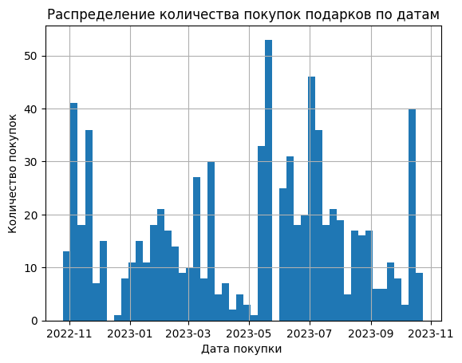

```python
df_gifts['date'].hist(bins=50)

plt.xlabel("Дата покупки ")
plt.ylabel("Количество покупок")
plt.title('Распределение количества покупок подарков по датам')
plt.show()
```

Можно отметить тренды в покупках подарков - перед календарными праздниками - в ноябре и декабре, в начале мая и летом, небольшой всплеск перед мартом

```python
df_gifts['date'].max()
```

```
Timestamp('2023-10-24 00:00:00')
```